# PSTAT 131 Final

Brianna Mao

December 08, 2022

## Data

Accurate predictions about election results are highly sought after, and looking at an individual voter’s data is one way to predict who may win.

We use the [county-level 2020 USA presidential election results](https://www.kaggle.com/datasets/unanimad/us-election-2020?select=president_county.csv) by Raphael Fontes and the [2017 United States county-level census data](https://www.kaggle.com/datasets/muonneutrino/us-census-demographic-data) by Muonneutrino to analyze and predict election winners.

1. The presidential election data, referred to as `election.raw`, consists of 32,177 observations of 5 variables: `state`, `county`, `candidate`, `party`, and `total_votes`. There are no missing values in the data set, and all 50 states and 1 federal district are accounted for.
2. The 2017 census data, referred to as `census`, consists of 3,220 observations of 37 variables, which include population, ethnicity, income, employment, and more. There is one observation that has missing values (Kalawao County in Hawaii, which is missing data on the percentage of children under the poverty level).

   There is a total of 3,220 counties in the `census` dataset; however, the `election.raw` dataset has 4,633 counties. Upon further inspection, some of the counties in the `election.raw` dataset are in fact cities, such as Roxbury, Connecticut which is located in Litchfield County. For the sake of this project, these can be ignored.
3. To make analysis of the data easier, we construct a state-level summary, `election.state`, and a federal-level summary, `election.total`. The first few rows of `election.state` are as follows:

   | state | candidate | party | total_votes |
   | --- | --- | --- | --- |
   | Alabama | Joe Biden | DEM | 849648 |
   | Alabama | Jo Jorgensen | LIB | 25176 |
   | Alabama | Donald Trump | REP | 1441168 |
   | Alabama | Write-ins | WRI | 7312 |
   | Alaska | Rocky De La Fuente | ALI | 318 |

   The first few rows of `election.total` are as follows.

   | candidate | party | total_votes |
   | --- | --- | --- |
   | Rocky De La Fuente | ALI | 88158 |
   | Blake Huber | APV | 409 |
   | Brian Carroll | ASP | 25256 |
   | Jerome Segal | BAR | 5949 |
   | Gary Swing | BFP | 141 |

4. There were 38 named presidential candidates total in the 2020 election, and the number of votes each received can be seen below. The votes were plotted on the log scale in order to make visualization easier and does not affect the actual results.

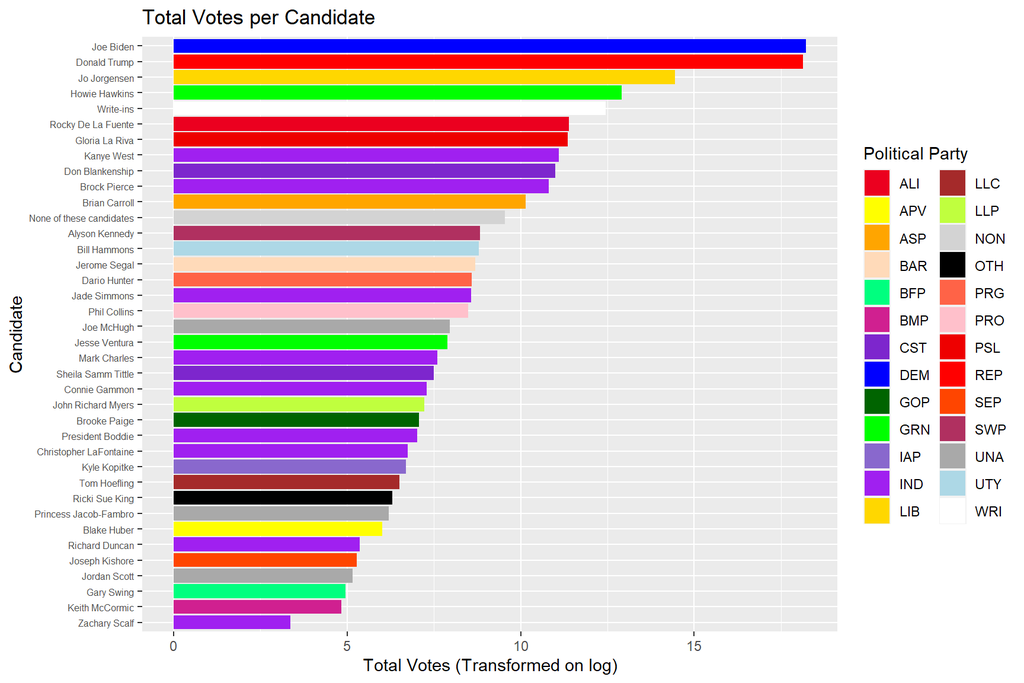

5. The winner in each county is saved in the dataset `county.winner` and the winner in each state is saved in the dataset `state.winner`. The first few rows of `county.winner` are as follows:

   | state | county | candidate | party | total_votes | total | pct |
   | --- | --- | --- | --- | --- | --- | --- |
   | Delaware | Kent | Joe Biden | DEM | 44552 | 87025 | 0.5119448 |
   | Delaware | New Castle | Joe Biden | DEM | 195034 | 287633 | 0.6780655 |
   | Delaware | Sussex | Donald Trump | REP | 71230 | 129352 | 0.5506679 |
   | District of Columbia | District of Columbia | Joe Biden | DEM | 39041 | 41681 | 0.9366618 |
   | District of Columbia | Ward 2 | Joe Biden | DEM | 29078 | 32881 | 0.8843405 |

   The first few rows of `state.winner` are as follows:

   | state | candidate | party | total_votes | total | pct |
   | --- | --- | --- | --- | --- | --- |
   | Arizona | Joe Biden | DEM | 1672143 | 3387326 | 0.4936469 |
   | California | Joe Biden | DEM | 11109764 | 17495906 | 0.6349922 |
   | Colorado | Joe Biden | DEM | 1804352 | 3256953 | 0.5540000 |
   | Connecticut | Joe Biden | DEM | 1080680 | 1824280 | 0.5923871 |
   | Delaware | Joe Biden | DEM | 296268 | 504010 | 0.5878217 |

## Visualization

Using maps is an easy way to show results in a simple manner. For example, a list of 3,000 counties can instead be shown as a single visual:

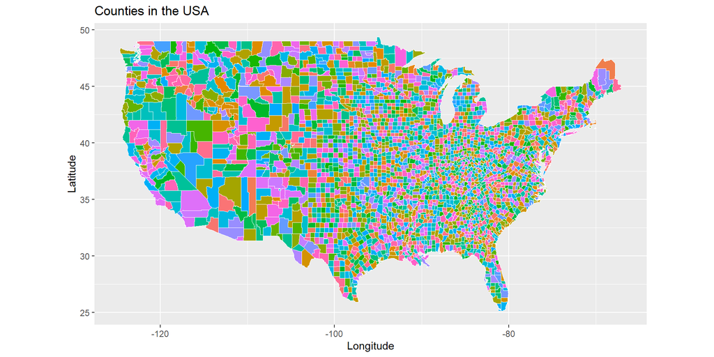

Likewise, the winner of the election in each state can be plotted onto a map of all 50 states:

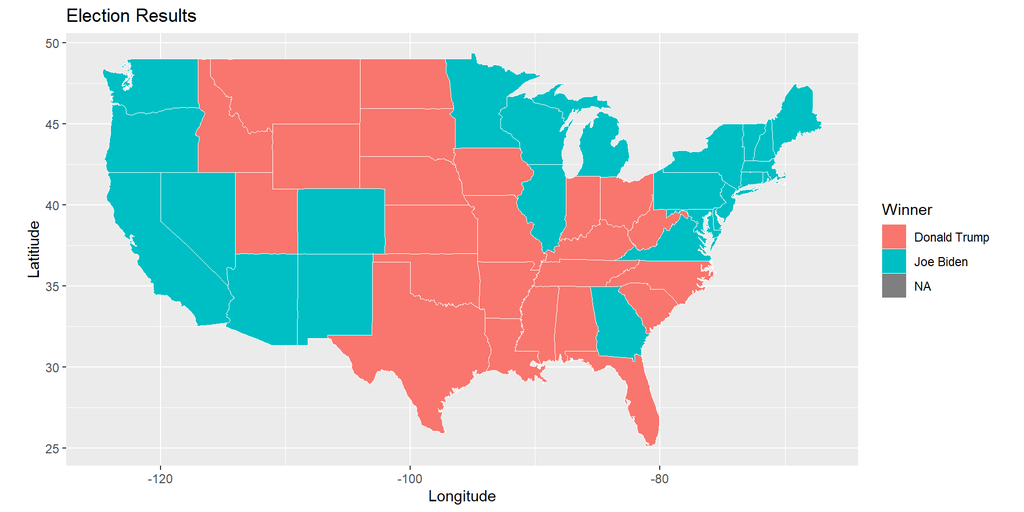

And the winner of the election in each county for a state can be plotted onto a map of the state:

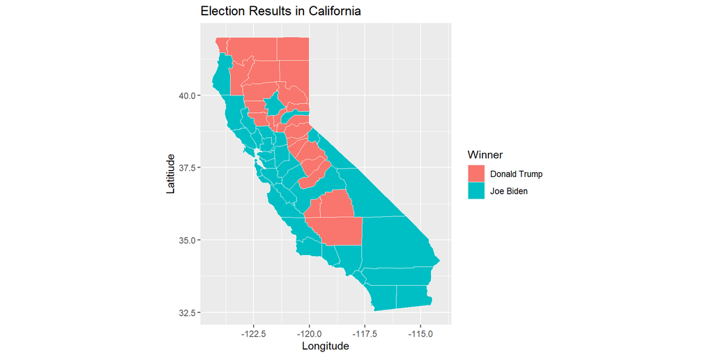

9. Demographics seem to play a role in which candidate voters choose. In particular, people often look at a voter’s race or income level when predicting which candidate a voter would vote for, as there are certain preconceptions regarding one’s race or income and their associated political party in the US. We can visualize these demographics as well by plotting the statistics for each county on a map by state:

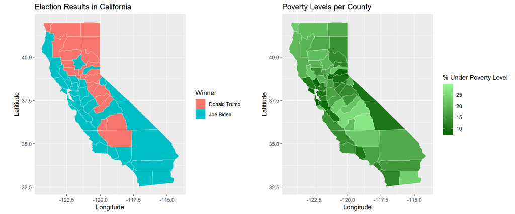

   Or overall:

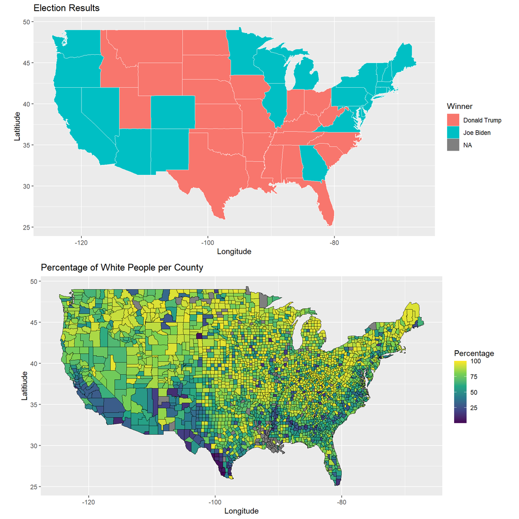

10. We still have many variables in the `census` dataset, not all of which may be important to include. We reduce the number of variables and save this as a new dataset, `census.clean`, by removing some variables that have high correlation with each other. The first 5 rows of `census.clean` are shown below:

    | CountyId | State | County | TotalPop | Men | White | VotingAgeCitizen | Income | Poverty | Professional | Service | Office | Production | Drive | Carpool | Transit | OtherTransp | WorkAtHome | MeanCommute | Employed | PrivateWork | SelfEmployed | FamilyWork | Unemployment |
    | --- | --- | --- | --- | --- | --- | --- | --- | --- | --- | --- | --- | --- | --- | --- | --- | --- | --- | --- | --- | --- | --- | --- | --- |
    | 1001 | Alabama | Autauga County | 55036 | 0.4887528 | 75.4 | 0.7452576 | 55317 | 13.7 | 35.3 | 18.0 | 23.2 | 15.4 | 86.0 | 9.6 | 0.1 | 1.3 | 2.5 | 25.8 | 0.4381132 | 74.1 | 5.6 | 0.1 | 5.2 |
    | 1003 | Alabama | Baldwin County | 203360 | 0.4894129 | 83.1 | 0.7640441 | 52562 | 11.8 | 35.7 | 18.2 | 25.6 | 10.8 | 84.7 | 7.6 | 0.1 | 1.1 | 5.6 | 27.0 | 0.4402390 | 80.7 | 6.3 | 0.1 | 5.5 |
    | 1005 | Alabama | Barbour County | 26201 | 0.5334148 | 45.7 | 0.7735964 | 33368 | 27.2 | 25.0 | 16.8 | 22.6 | 24.1 | 83.4 | 11.1 | 0.3 | 1.7 | 1.3 | 23.4 | 0.3388420 | 74.1 | 6.5 | 0.3 | 12.4 |
    | 1007 | Alabama | Bibb County | 22580 | 0.5425598 | 74.6 | 0.7821966 | 43404 | 15.2 | 24.4 | 17.6 | 19.7 | 22.4 | 86.4 | 9.5 | 0.7 | 1.7 | 1.5 | 30.0 | 0.3618689 | 76.0 | 6.3 | 0.3 | 8.2 |
    | 1009 | Alabama | Blount County | 57667 | 0.4940434 | 87.4 | 0.7372154 | 47412 | 15.6 | 28.5 | 12.9 | 23.3 | 19.5 | 86.8 | 10.2 | 0.1 | 0.4 | 2.1 | 35.0 | 0.3707493 | 83.9 | 4.0 | 0.1 | 4.9 |

## Clustering

Even after reduction, there are still quite some variables left in `census.clean`. We can perform Principal Component Analysis (PCA), which further reduces the dimensions of the data by finding principal components that are linear combinations of the original features.

11. PCA requires the data to be centered because the process requires each column of the data to have a mean of 0, which can be obtained by centering. We also scale the data because the features in the `census.clean` dataset are recorded on different scales (ie. `Men` is recorded in percent, `Income` is recorded in dollars).

    In the first principal component, `Employed`, `Poverty`, `Income` have the largest absolute values of the first principal component.

When performing PCA, some of the data in the first few principal components are lost in dimension reduction. To calculate how much of this information is lost, we can calculate the proportion of variance explained (PVE) for each principal component, which tells us how much variance each PC explains.

12. To calculate how many principal components are needed to capture a certain amount of the variance in the data, we can plot the cumulative proportion of variance explained (CPVE) and find where the number of PCs intercepts that threshold. Based on the plot below, we need a minimum of 13 PCs to capture 90% of the variance for analysis.

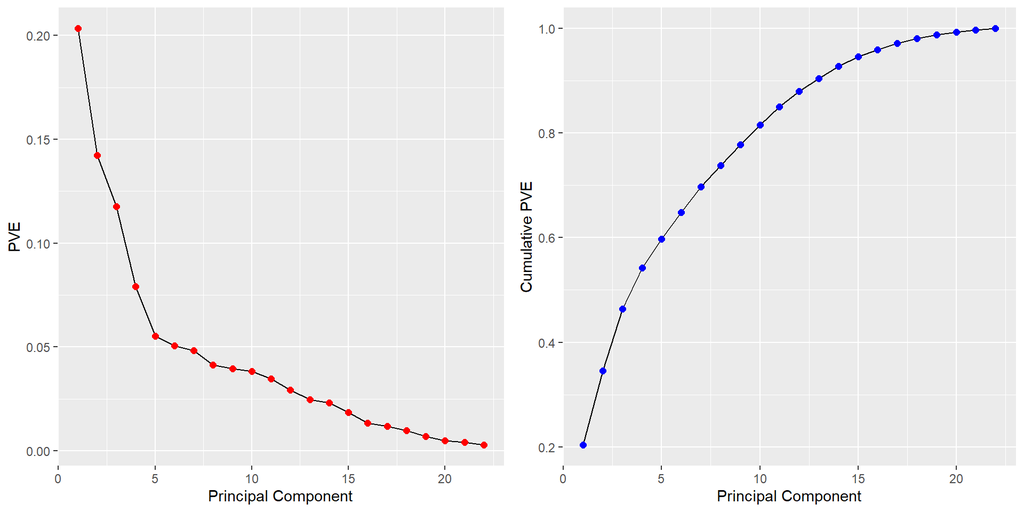

Another method of variable reduction is hierarchical clustering, which groups observations together into clusters.

13. We perform hierarchical clustering on `census.clean` to split the data into 10 clusters. We also perform hierarchical clustering on the first two principal components we obtained previously and split that into 10 clusters. The number of observations in each cluster can be seen as follows:

    ```
    ## census.clean.clustering
    ##    1    2    3    4    5    6    7    8    9   10
    ## 3057   87    2   48    9    1    2    5    7    1
    ```

    ```
    ## pc.clustering
    ##    1    2    3    4    5    6    7    8    9   10
    ## 1749  123  791  149   10  330    1   13   25   28
    ```

    Hierarchical clustering on `census.clean` sees most data falling into cluster 1 and much fewer observations in each of the other clusters, some of them with frequencies merely in the single digits. Clustering on the principal components also sees more observations in cluster 1, but in comparison, the number of observations in each cluster are more balanced, as more clusters have observations in the triple digits.

    We can observe the datapoint Santa Barbara County to see which method provides the better cluster. We calculate the average statistics for the cluster that contains Santa Barbara County while excluding Santa Barbara County for both methods of clustering, then compare those averages with the data for Santa Barbara County. Hierarchical clustering on `census.clean` seemed to put Santa Barbara County in the most appropriate cluster, because more of the averages align with the data seen in Santa Barbara County. This may be because clustering performed on the first two principal components do not capture a lot of variability in the data, and thus are not as accurate compared to clustering on `census.clean`, which contains all of the original data.

    |  | TotalPop | Men | White | VotingAgeCitizen | Income | Poverty | Professional | Service | Office | Production | Drive | Carpool | Transit | OtherTransp | WorkAtHome | MeanCommute | Employed | PrivateWork | SelfEmployed | FamilyWork | Unemployment |
    | --- | --- | --- | --- | --- | --- | --- | --- | --- | --- | --- | --- | --- | --- | --- | --- | --- | --- | --- | --- | --- | --- |
    | Santa Barbara County | 442996.00 | 0.5010316 | 45.30 | 0.6343376 | 68023.00 | 15.40 | 35.20 | 21.70 | 21.00 | 8.10 | 68.00 | 13.60 | 3.20 | 4.80 | 5.80 | 19.40 | 0.4780924 | 75.70 | 8.10 | 0.20 | 6.60 |
    | census.clean Clustering | 579741.24 | 0.4900000 | 62.66 | 0.7100000 | 65507.08 | 12.85 | 39.66 | 17.26 | 24.01 | 10.84 | 76.98 | 8.93 | 4.87 | 1.84 | 4.86 | 26.67 | 0.4900000 | 81.48 | 5.29 | 0.14 | 6.27 |
    | PC Clustering | 30590.62 | 0.5100000 | 22.40 | 0.7500000 | 24955.64 | 38.45 | 26.55 | 23.14 | 22.89 | 15.35 | 82.56 | 9.77 | 0.66 | 1.42 | 2.75 | 25.58 | 0.2900000 | 68.60 | 7.02 | 0.20 | 14.45 |

## Classification

By combining the election results data and the census data, we can create a dataset that contains both demographics and election winners in each county, which can be used to predict election winners under different models.

14. When creating this dataset, `election.cl`, we drop all other predictor variables that are not numeric variables, such as `party`, because we are only interested in predicting the election winner `Candidate` using the demographic data. `party` is a qualitative variable, thus cannot be used to perform calculations involving mathematical operations. The first few rows of `election.cl` are shown below:

    | candidate | TotalPop | Men | White | VotingAgeCitizen | Income | Poverty | Professional | Service | Office | Production | Drive | Carpool | Transit | OtherTransp | WorkAtHome | MeanCommute | Employed | PrivateWork | SelfEmployed | FamilyWork | Unemployment |
    | --- | --- | --- | --- | --- | --- | --- | --- | --- | --- | --- | --- | --- | --- | --- | --- | --- | --- | --- | --- | --- | --- |
    | Joe Biden | 173145 | 0.4825089 | 62.7 | 0.7399232 | 57647 | 13.0 | 33.5 | 19.8 | 22.9 | 13.8 | 82.1 | 9.6 | 1.2 | 1.1 | 4.2 | 26.3 | 0.4509400 | 74.7 | 4.0 | 0.2 | 6.7 |
    | Joe Biden | 555036 | 0.4843253 | 58.5 | 0.7272357 | 68336 | 11.9 | 43.9 | 17.0 | 23.4 | 8.7 | 80.5 | 7.7 | 4.0 | 1.1 | 4.2 | 25.7 | 0.4849487 | 84.7 | 3.2 | 0.1 | 6.5 |
    | Donald Trump | 215551 | 0.4848690 | 74.9 | 0.7681384 | 57901 | 12.0 | 33.3 | 18.7 | 24.0 | 12.8 | 83.4 | 7.3 | 0.7 | 1.3 | 5.6 | 25.3 | 0.4373489 | 79.3 | 5.8 | 0.1 | 6.1 |
    | Joe Biden | 672391 | 0.4744948 | 36.0 | 0.7482432 | 77649 | 17.4 | 61.7 | 15.3 | 16.7 | 3.6 | 34.0 | 5.4 | 35.4 | 6.2 | 5.7 | 30.0 | 0.5319836 | 71.0 | 4.3 | 0.1 | 8.0 |
    | Joe Biden | 259865 | 0.4837589 | 62.0 | 0.7715160 | 45478 | 23.3 | 46.1 | 19.2 | 23.3 | 6.2 | 74.7 | 8.8 | 4.1 | 4.6 | 4.5 | 21.2 | 0.4635715 | 70.2 | 4.2 | 0.1 | 6.6 |

15. A decision tree is a simple way to visualize and understand how predictors lead to a classification. However, they often do not have good accuracy, and when they are large, the tree tends to overfit the data. Thus, a tree is pruned to a size determined through cross-validation, and a large tree …

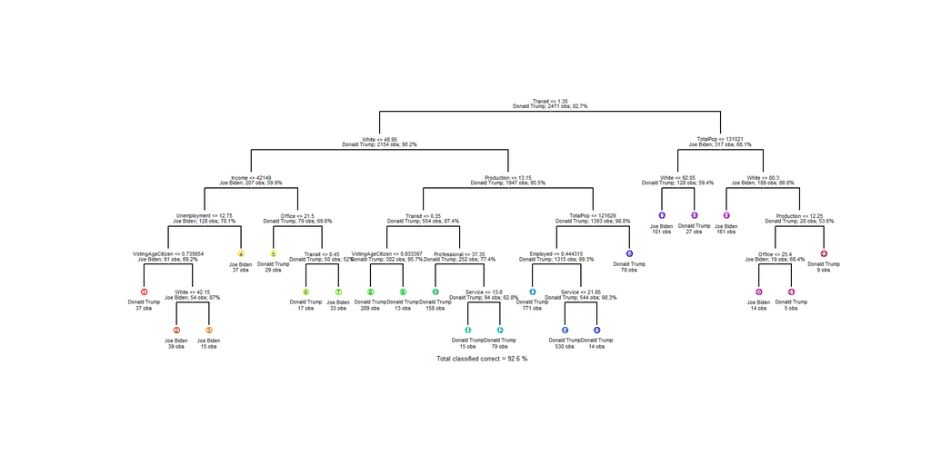

    will now look much smaller:

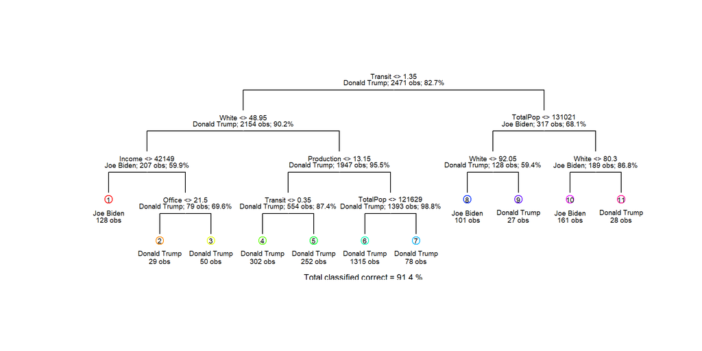

    ```
    ##
    ## Call:
    ## glm(formula = candidate ~ ., family = "binomial", data = election.tr)
    ##
    ## Deviance Residuals:
    ##     Min       1Q   Median       3Q      Max
    ## -4.4340  -0.2463  -0.1001  -0.0341   3.3104
    ##
    ## Coefficients:
    ##                    Estimate Std. Error z value Pr(>|z|)
    ## (Intercept)      -3.982e+01  6.245e+00  -6.376 1.82e-10 ***
    ## TotalPop          1.632e-06  6.161e-07   2.649  0.00807 **
    ## Men               2.184e+00  4.357e+00   0.501  0.61625
    ## White            -1.264e-01  9.170e-03 -13.780  < 2e-16 ***
    ## VotingAgeCitizen  1.872e+01  2.526e+00   7.411 1.25e-13 ***
    ## Income           -8.804e-06  1.609e-05  -0.547  0.58424
    ## Poverty           5.305e-02  2.834e-02   1.872  0.06124 .
    ## Professional      2.953e-01  3.726e-02   7.924 2.30e-15 ***
    ## Service           3.343e-01  4.436e-02   7.536 4.86e-14 ***
    ## Office            1.171e-01  4.505e-02   2.599  0.00934 **
    ## Production        1.791e-01  3.974e-02   4.506 6.60e-06 ***
    ## Drive            -1.025e-01  3.519e-02  -2.912  0.00359 **
    ## Carpool          -8.037e-02  4.654e-02  -1.727  0.08418 .
    ## Transit           2.347e-01  8.700e-02   2.698  0.00698 **
    ## OtherTransp       1.481e-01  8.833e-02   1.677  0.09354 .
    ## WorkAtHome        5.993e-02  5.993e-02   1.000  0.31737
    ## MeanCommute       3.831e-02  2.302e-02   1.664  0.09602 .
    ## Employed          2.643e+01  3.156e+00   8.375  < 2e-16 ***
    ## PrivateWork       5.527e-02  2.005e-02   2.756  0.00586 **
    ## SelfEmployed     -2.130e-02  4.247e-02  -0.501  0.61611
    ## FamilyWork       -4.465e-01  2.823e-01  -1.581  0.11381
    ## Unemployment      2.537e-01  4.233e-02   5.994 2.05e-09 ***
    ## ---
    ## Signif. codes:  0 '***' 0.001 '**' 0.01 '*' 0.05 '.' 0.1 ' ' 1
    ##
    ## (Dispersion parameter for binomial family taken to be 1)
    ##
    ##     Null deviance: 2274.83  on 2470  degrees of freedom
    ## Residual deviance:  853.39  on 2449  degrees of freedom
    ## AIC: 897.39
    ##
    ## Number of Fisher Scoring iterations: 7
    ```

    After fitting a logistic regression model to the data, we find that extremely significant variables include `White`, `VotingAgeCitizen`, `Professional`, `Service`, `Production`, `Employed`, and `Unemployment`. This is not consistent with the decision tree because only the variables `White` and `Production` are considered significant in both models.

    The coefficients in a logistic regression models can be interpreted easily. For example, the `White` coefficient -0.1264 indicates for every 10% increase in the percentage of the population in a county that is white, the log(odds) of Joe Biden winning that county decreases by -1.264 (or conversely, the log(odds) of Donald Trump winning the county increases by 1.264), conditional on all other predictors. The `Employed` coefficient of 26.43 indicates that for every 1% increase in the percentage of the population in a county that is employed, the log(odds) of Joe Biden winning that county increases by 26.43, conditional on all other predictors.
17. In our logistic regression model, we receive a warning that we are overfitting the data. One way to combat this is to perform variable selection through LASSO regression. Through cross-validation, we determine the optimal size for the tuning parameter $\lambda$ is 0.0004. The resulting model sets some coefficients to 0, shown below:

    ```
    ##      (Intercept)         TotalPop              Men            White
    ##          -1.9307           0.0000           0.0000          -0.0091
    ## VotingAgeCitizen           Income          Poverty     Professional
    ##           1.2383           0.0000           0.0112           0.0208
    ##          Service           Office       Production            Drive
    ##           0.0187           0.0062           0.0100          -0.0099
    ##          Carpool          Transit      OtherTransp       WorkAtHome
    ##          -0.0062          -0.0048           0.0128          -0.0019
    ##      MeanCommute         Employed      PrivateWork     SelfEmployed
    ##           0.0039           1.5870           0.0035          -0.0022
    ##       FamilyWork     Unemployment
    ##          -0.0180           0.0160
    ```

    The model leaves us with the variables `White`, `VotingAgeCitizen`, `Poverty`, `Professional`, `Service`, `Office`, `Production`, `Drive`, `Carpool`, `Transit`, `OtherTransp`, `WorkAtHome`, `MeanCommute`, `Employed`, `PrivateWork`, `SelfEmployed`, `FamilyWork`, and `Unemployment`.

    The LASSO regression model considers many variables that the logisitc regression model does not consider significant, such as `Poverty`, `Carpool`, `OtherTransp`, `WorkAtHome`, `MeanCommute`, `SelfEmployed` and `FamilyWork`. Even so, both models find `White`, `VotingAgeCitizen`, `Professional`, `Service`, `Office`, `Production`, `Drive`, `Transit`, `Employed`, `PrivateWork`, and `Unemployment` are significant variables.
18. Model performance can be visualized by an ROC plot, which displays the true positive rate and the false positive rate for a model. Models with a better overall performance have an area under the curve closer to 1. The ROC plot for our decision tree, logistic regression model, and LASSO regression model is shown below:

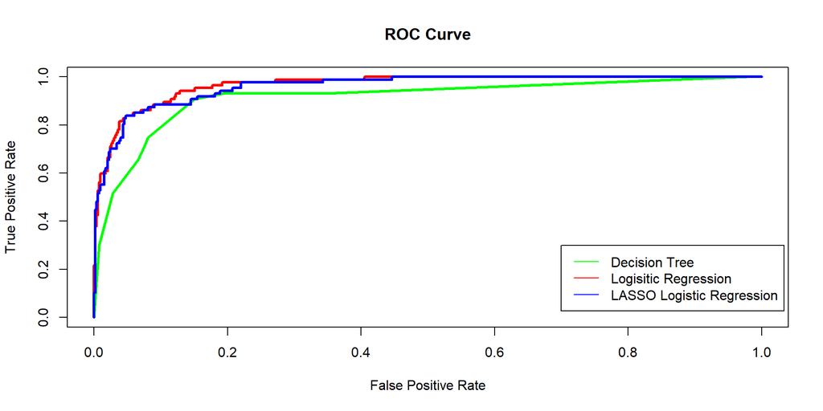

    The graph shows that the logistic regression model seems to have the best performance of the three models. This is supported by the test error rates for the three fitted models:

    |  | train.error | test.error |
    | --- | --- | --- |
    | tree | 0.08619992 | 0.10517799 |
    | logistic | 0.06879806 | 0.06148867 |
    | lasso | 0.07608256 | 0.06957929 |

    Decision trees are simpler to visualize and understand, but are often very inaccurate. Logistic regression provides a linear model for binary classification, which is easy to interpret and infer, but in this case uses many variables, which causes overfitting and may not actually fit new data accurately. LASSO regularization can perform variable selection and potentially reduce variance by increasing bias. However, the interpretation of the coefficients in logistic regression and LASSO regularization on a logistic model must be in terms of the log(odds) of the response, which may be harder for casual observers to comprehend. Logistic regression and LASSO logistic regression are both linear models which may not work well when the true data is more flexible, whereas decision trees can handle this flexibility.

    These models can help tackle different questions regarding this dataset. LASSO regularization can be used to answer which variables are more important in determining the results of the election in a model. Logistic regression can shed insight on how each variable affects the results.

## Extensions

19. A single decision tree can have low predictive accuracy, but multiple trees together can improve prediction accuracy by lowering the variance.

    We fit a random forest model and find that the out-of-bag error estimate is 0.0676 and the test error rate is 0.0647. The random forest considers `White`, `Transit`, and `TotalPop` to be the 3 most significant variables, which is similar to the variables chosen in the decision tree.

    We can also use a support vector machine to perform classification. A support vector machine divides predictions with a hyperplane so that the data is mostly separated, with some allowance in the margins or even on the wrong side of the hyperplane.

    We fit a support vector machine with a polynomial kernel so that it is more flexible than linear-based models and calculate the test error rate. The training and test error rates for all five models are as follows:

    |  | train.error | test.error |
    | --- | --- | --- |
    | tree | 0.08619992 | 0.10517799 |
    | logistic | 0.06879806 | 0.06148867 |
    | lasso | 0.07608256 | 0.06957929 |
    | randForest | 0.00000000 | 0.06472492 |
    | svm | 0.05787131 | 0.06957929 |

    The logistic regression model still provides the lowest test error rate of these five models. The random forest and support vector machine provide better prediction accuracy than a decision tree, but are also harder to interpret compared to the linear-based models like logistic regression and LASSO regularized logistic regression.
20. The votes from “swing counties” can influence the results of the elections. Both candidates are almost equally likely to win in those counties, which can make them highly contested targets of campaigns and ads. We consider swing counties as counties where the winning candidate won only 47% to 53% of the toal votes in the county. Based on the 2020 election results, there were 599 actual swing counties, shown below in purple:

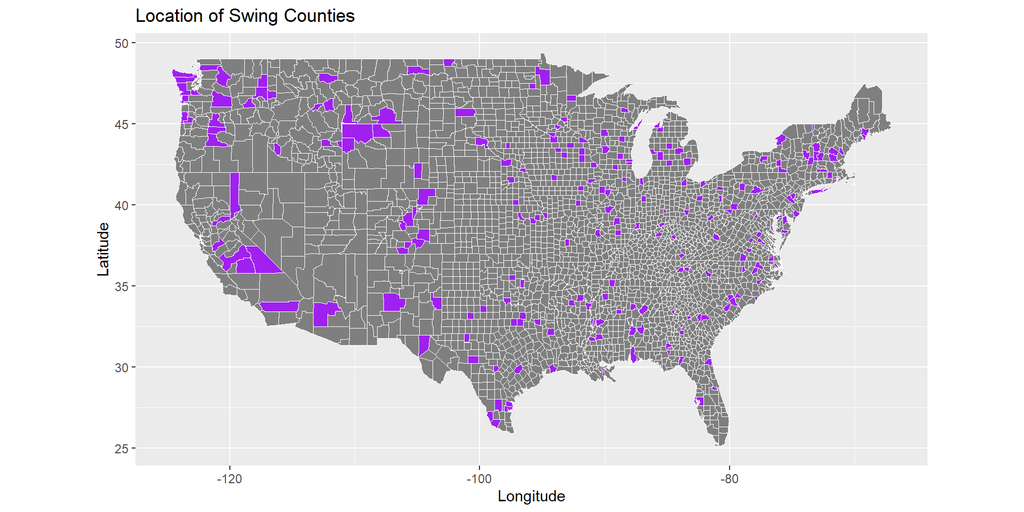

    We use the logistic regression model and predict which counties will be swing counties. The logistic regression model predicted 29 counties would be swing counties, and the error rate for predicted winners for those counties is 0.5517. The location of correct predictions are shown below in green and incorrect predictions in red:

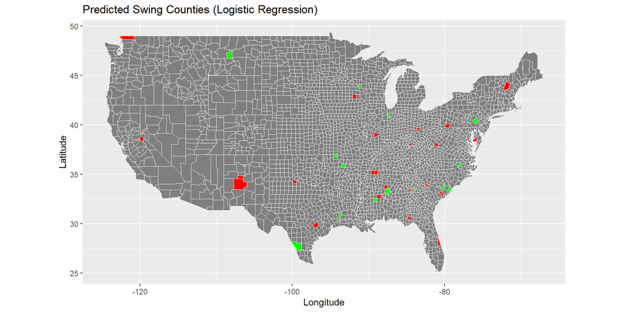

    We repeat this process using the LASSO regularized logistic model. The LASSO model predicted 86 counties would be swing counties, and the error rate for predicted winners for those counties is 0.4302, which is lower than the error rate from logistic regression. The location of correct predictions are shown below in green and incorrect predictions in red:

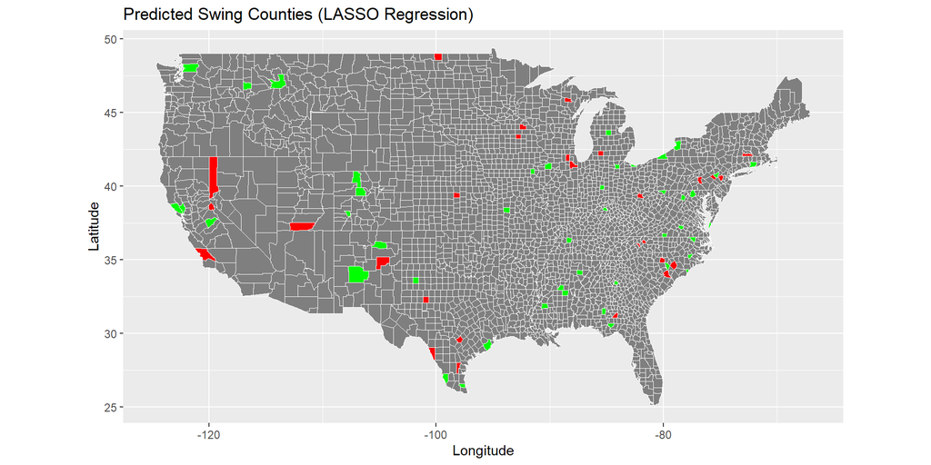

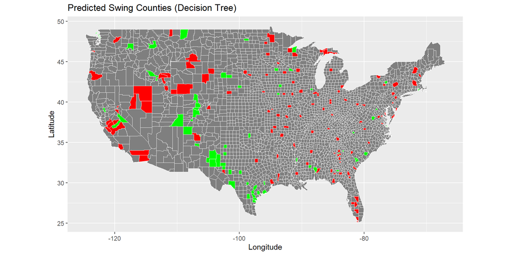

    We look at the variables to attempt to explain why these counties are swing counties. The densities of the variables based on the logistic regression model are plotted based on whether the county is predicted to be a swing county, vote for Joe Biden, or vote for Donald Trump. Some densities show little difference between the three, thus a couple of selected variables that do seem to show an interesting difference in their densities are shown below:

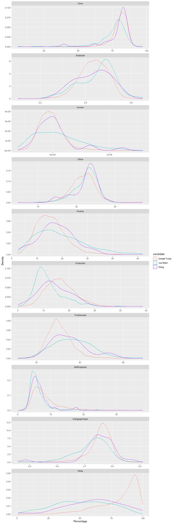

    As expected, the data from swing counties usually falls between the data from counties where Joe Biden won significantly and counties where Donald Trump won significantly. Sometimes, the swing county data has densities even greater than the densities of Biden counties and Trump counties, such as in `Drive` and `Office`. Some densities look extremely different between counties that voted for Biden and Trump. For example, Trump counties have on average lower percentages of people employed, more lower incomes, and much higher percentages of white people compared to Biden counties.

    Of the 10 variables selected here, 5 of them are considered extremely significant in the logistic regression model: `White`, `VotingAgeCitizen`, `Professional`, `Production`, and `Employed`. Of those 5 variables, only 1 of them has a negative coefficient, `White`.
21. All three models used to predict swing counties predicted that there would be far fewer swing counties than there were in reality. From the above analysis, we can say that swing counties are hard to predict because the values of some of the variables are more like Trump counties and some of the values of the variables are more like Biden counties. It appears that what field of work a voter is in also greatly affects who they will vote for, as those employed in the production field tend to vote for Trump and those employed in the professional fields tend to vote for Biden. Swing counties tend to be more similar to Trump counties in regards to `Production` but closer to Biden counties in regards to `Professional`; thus the calculated probabilities of who would win the county will fall somewhere in the middle. The stark difference between Trump counties and Biden counties in the graphical display of the `White` variable indicates that it is a key variable in predicting the response, and a high percentage of white people in a county means it is likelier that Donald Trump wins the county, provided all other variables remain the same.

    The logistic regression model was used to provide an interpretation because the variables are easier to interpret as we assume linearity of the predictors. However, it is unreasonable to assume that data in the real world will be linear, so while the logistic regression model has the lowest test error rate of the 5 models we tried, it may not be the best model for new data. The census data is also from 2017, which may be outdated to use to predict election results in 2020. Using 2020 census data to predict election results may provide more accurate predictions for the information we want to know. Experts who have studied population demographics to predict election results may also have insight based on their prior knowledge on what type of model would provide the best predictions, including what kernels to specify in model fits and what range one should look at when considering different tuning parameters.